# **Analysis of cycling facilities in Paris by arrondissement**

## **1.Introduction of the data used**

### **1.1Main dataset about the bike facilities**

The following dataset has been choose on the following source Réseau des itinéraires cyclables de la ville de Paris

It is the main source of this analysis. Indeed, this dataset contains many interesting information such as the length of the cycle tracks, their location, the date of construction, their type etc…

It contains 12 255 records with 18 variables each (although not all records have all variables)

*The dataset has been downloaded the 16 th december so all the bike facilities after this date have not been taking into account*

| Typologie | Aménagement.bidirectionnel | Régime.de.vitesse | Sens.vélo | Voie | Arrondissement | Bois | Longueur.du.tronçon.en.m | Longueur.du.tronçon.en.km | Position.aménagement | Circulation.générale.interdite | Piste | Couloir.bus | Continuité.cyclable | Réseau.cyclable | Date.de.livraison | geo_shape | geo_point_2d |
| --- | --- | --- | --- | --- | --- | --- | --- | --- | --- | --- | --- | --- | --- | --- | --- | --- | --- |
| 4 | 2 | 1 | 1 | BOULEVARD DE MAGENTA | 10 | 1 | 84.72473247 | 0.08472473247000001 | NA |  | 2 | NA | NA | NA | 2008-12-31 | {“coordinates”: [[2.351370630741908, 48.881341030310196], [2.3519593648303, 48.88068546551617]], “type”: “LineString”} | 48.88101324791319,2.3516649977861035 |
| 1 | 2 | 2 | 2 | RUE CHAMPIONNET | 18 | 1 | 117.83625507 | 0.11783625507 | NA |  | NA | NA | NA | NA | 2018-12-31 | {“coordinates”: [[2.3466073909301506, 48.89577593518674], [2.347591981746986, 48.89566760570355], [2.3481932153086413, 48.895603790355565]], “type”: “LineString”} | 48.895689146219134,2.3474002256727458 |

### **1.2 Dataset used for the bicyle facilities**

As explained before, the dataset from Paris city is huge so only the data needed has been taking into account for the analysis in order to facilitate the processing

Therefore the dataset used contains 12 254 (indeed one row was NULL) records with 8 variables each (although not all records have all variables).

Information concerning the distance, the type and the arrondissement has been kept

| Typologie | Aménagement.bidirectionnel | Régime.de.vitesse | Sens.vélo | Arrondissement | Bois | Longueur.du.tronçon.en.m | Longueur.du.tronçon.en.km |
| --- | --- | --- | --- | --- | --- | --- | --- |
| 4 | 2 | 1 | 1 | 10 | 1 | 84.72473247 | 0.08472473247000001 |
| 1 | 2 | 2 | 2 | 18 | 1 | 117.83625507 | 0.11783625507 |
| 4 | 1 | 1 | 1 | 14 | 1 | 20.24016374 | 0.02024016374 |
| 5 | 1 | 5 | 1 | 4 | 1 | 36.75370121 | 0.03675370121 |

### **1.3 Arrondissement shapefile used**

In order to display the data on a map, a shapefile from [data gouv](https://www.data.gouv.fr/fr/datasets/arrondissements-1/#resources) has been used.

This has allowed to display data per arrondissement on a map.

| n_sq_ar | c_ar | c_arinsee | l_ar | l_aroff | n_sq_co | surface | perimetre | geometry |
| --- | --- | --- | --- | --- | --- | --- | --- | --- |
| 7.5e+08 | 11 | 75111 | 11ème Ardt | Popincourt | 750001537 | 3665441.6 | 8282.012 | POLYGON ((2.396237 48.85415… |
| 7.5e+08 | 2 | 75102 | 2ème Ardt | Bourse | 750001537 | 991153.7 | 4554.104 | POLYGON ((2.351518 48.86443… |
| 7.5e+08 | 6 | 75106 | 6ème Ardt | Luxembourg | 750001537 | 2153095.6 | 6483.687 | POLYGON ((2.344593 48.85405… |
| 7.5e+08 | 12 | 75112 | 12ème Ardt | Reuilly | 750001537 | 16314782.6 | 24089.666 | POLYGON ((2.41388 48.83357,… |
| 7.5e+08 | 17 | 75117 | 17ème Ardt | Batignolles-Monceau | 750001537 | 5668834.5 | 10775.580 | POLYGON ((2.295167 48.87396… |
| 7.5e+08 | 4 | 75104 | 4ème Ardt | Hôtel-de-Ville | 750001537 | 1600585.6 | 5420.908 | POLYGON ((2.368512 48.85573… |
| 7.5e+08 | 16 | 75116 | 16ème Ardt | Passy | 750001537 | 16372542.1 | 17416.110 | POLYGON ((2.274264 48.87837… |

### **1.4 Surface per arrondissement**

Data regarding the surface of the Arrondissement has been extract from the shapefile in order to process the distribution of bicyle path.

*A column Name has been added to be displayed in order to facilitate the understanding of the map for the users*

| Arrondissement | Name | surface_in_km2 |
| --- | --- | --- |
| 1 | 1 er Arrondissement: | 1.83 |
| 2 | 2 ème Arrondissement: | 0.99 |
| 3 | 3 ème Arrondissement: | 1.17 |
| 4 | 4 ème Arrondissement: | 1.60 |
| 5 | 5 ème Arrondissement: | 2.54 |
| 6 | 6 ème Arrondissement: | 2.15 |
| 7 | 7 ème Arrondissement: | 4.09 |
| 8 | 8 ème Arrondissement: | 3.88 |
| 9 | 9 ème Arrondissement: | 2.18 |
| 10 | 10 ème Arrondissement: | 2.89 |
| 11 | 11 ème Arrondissement: | 3.67 |

## **2.Distribution of cycling infrastructure**

### **2.1Length of cycling facilities by arrondissement**

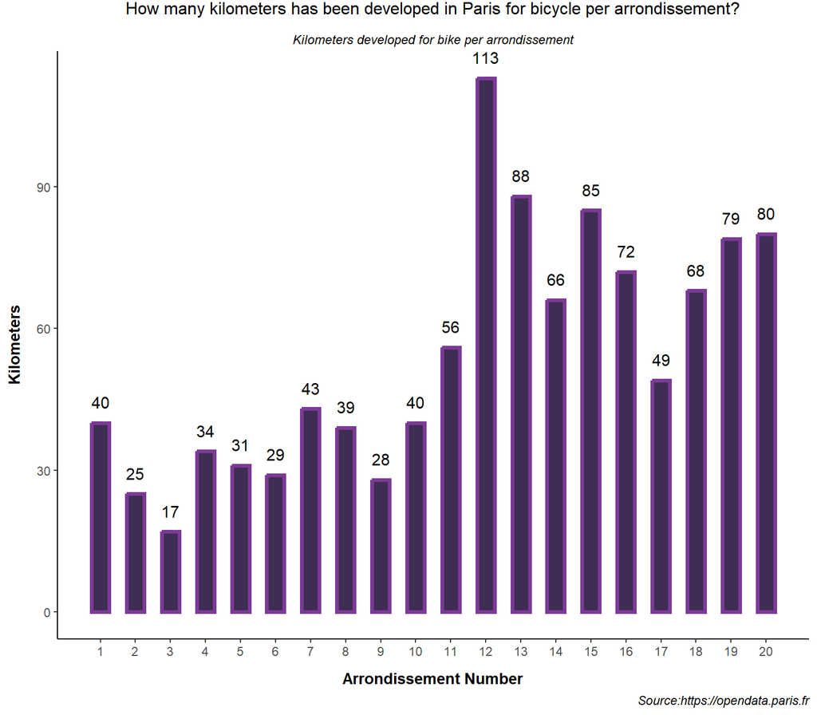

Does this mean that the larger arrondissements are better equipped for cyclists? Absolutely not, in fact the arrondissements vary greatly in size, so it would be more appropriate to compare the length of cycle track available according to the size of the arrondissement.

### **2.2How to effectively compare cycling facilities between arrondissements ?**

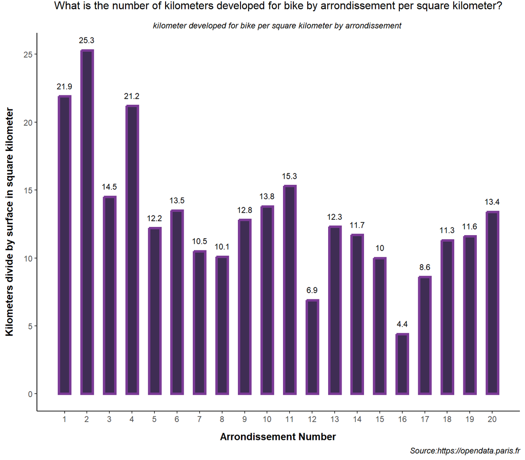

It would have been interesting to compare the number of kilometers of total streets with the number of kilometers of cycle paths per arrondissement in order to know which arrondissement are the best equipped for cyclists. However, the number of kilometers of total street per arrondissement was not found.

Otherwise, on the whole, it can be said that cycle facilities are equivalent depending on the arrondissement, except for the 12th and 16th arrondissements, which have 6.9 km and 4.4 km of cycle paths per square kilometre respectively. In order to determine an explanation for these results, the distribution of cycle tracks on a map was carried out.

### **2.3How are cycling facilities distributed in Paris?**

**The localisation of facilities developed for bike per arrondissement by measuring kilometer developed for bike per square kilometer**

[interactive chart not shown]

Unsurprisingly, the centre of Paris has the best cycling facilities. Indeed, this is the part of the city where most people pass through and go. Therefore, the city council had to favour this area for cycling facilities. On the other hand, it is now easier to understand why the 12th and 16th arrondissements have a low rate of km of cycle track per square kilometre. The 16th arrondissement includes the Bois de Boulogne and the 12th arrondissement the Bois de Vincennes. This increases their surface area and it is not in the parks that we will find a large number of cycle paths. The analysis for these two arrondissements is therefore a little skewed.

On the other hand, it can be seen that the north/north-east has a better cycle network than the other parts of the city, without any apparent explanation. For example, the 11th and 20th arrondissements have a high concentration of cycle paths even though they are not central arrondissements.

This difference can be explained by the different types of infrastructure put in place and counted as cycle routes when they do not have the same impact, e.g. shared lanes with buses are easier to put in place than real cycle paths. In part 3 this hypothesis will be studied in order to better understand these differences between the arrondissements

## **3.Type of cycling infrastructure**

### **3.1 What is the proportion of each type of infrastructure?**

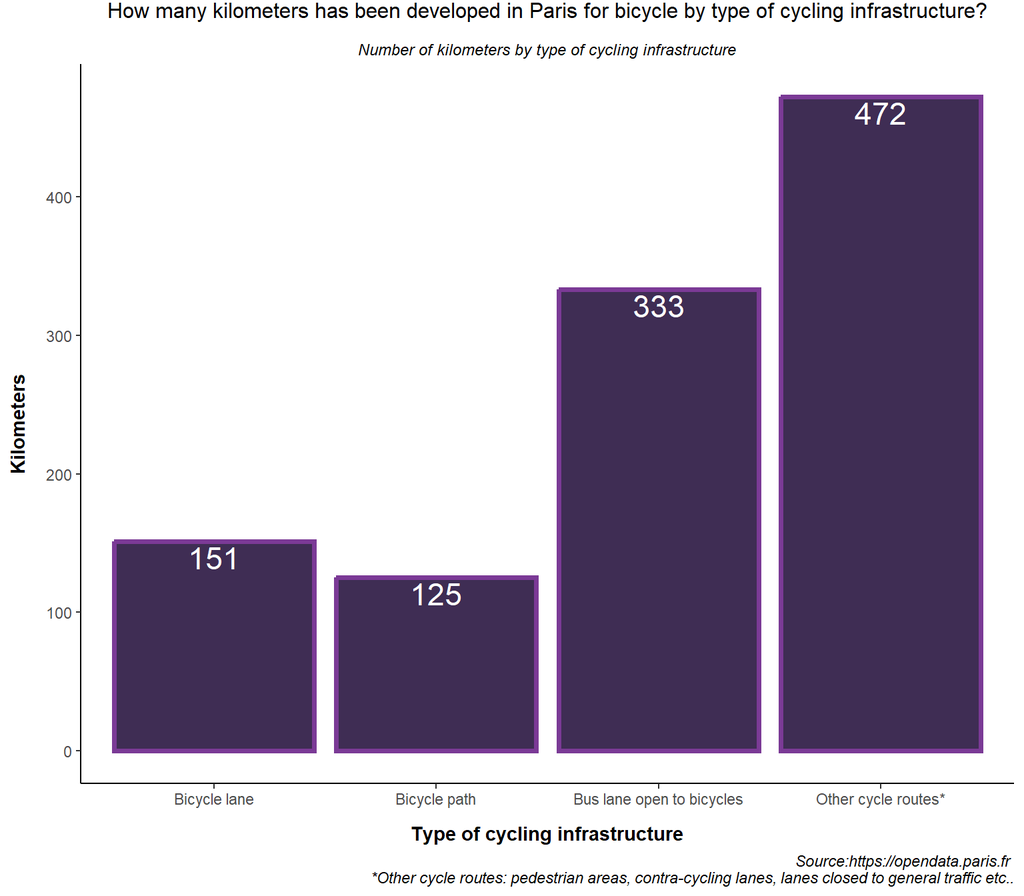

As this graph shows, it is the others cycle routes that are most present. In fact, there are almost four times as many as cycle paths in terms of kilometres. In second place are bus lanes open to bicycles, which are twice as important as bicycle lanes.

This result was entirely expected as there is no real construction for contra-cycling lanes, opening a bus lane for cyclists and allowing them access to pedestrian routes. Whereas a cycle lane and path require more resources and it is not necessarily possible to implement it everywhere.

### **3.2 Is the type of cycling infrastructures the cause of the differences between the districts?**

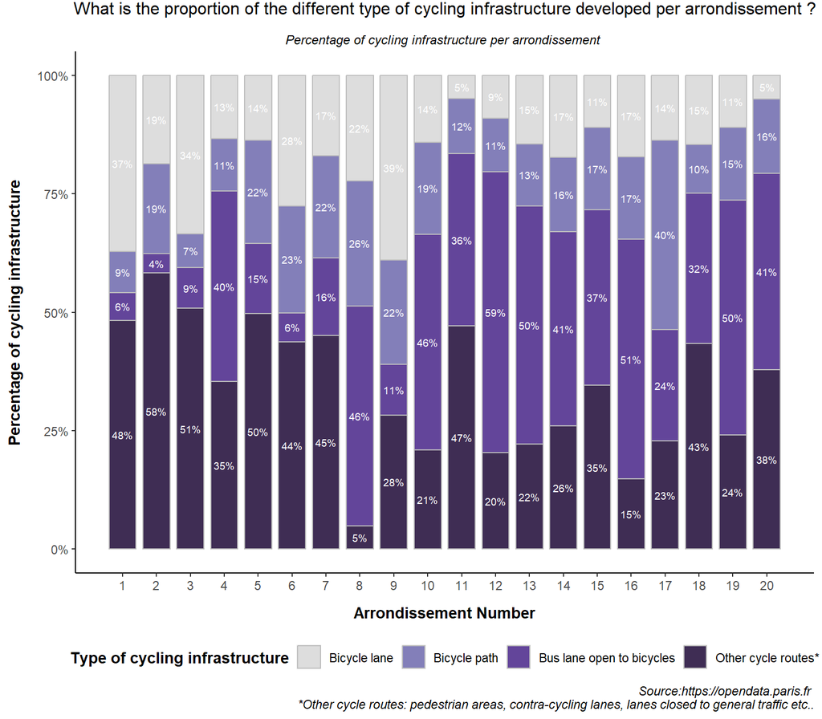

It was explained in part 2 that the 11th and 20th arrondissements have better cycling facilities than other arrondissements with a similar geographical position. When we look at this graph, we can see that their cycle track and lane provision is very low. In total, they represent barely 21% for the 20th arrondissement and 17% for the 11th arrondissement. Then, the 2nd arrondissement, which has the best score on the map, has almost 60% of other cycle routes. It therefore seems that the type of infrastructure plays an important role.

However, it is not totally decisive because the 8th arrondissement, which has 10 km of infrastructure per square kilometre (which is a normal result given its location in Paris), has 50% of its infrastructure in the form of cycle paths and lanes and only 5% of other cycle roads. Therefore, it is possible to have enough cycle infrastructure and still have a significant proportion of cycle lanes and paths.

## **Conclusion**

### **Conclusion**

At first glance, the bicycle facilities between the boroughs are really different. In fact, if we measure the kilometer of facilities, we find big differences. However, if we relate these distances to the size of the arrondissements, we can see that the differences are not so great even if the arrondissements in the center of Paris have proportionally more bicycle facilities than the others.

For the other arrondissements, the difference in facilities can be measured according to the type of bicycle facility chosen and whether the arrondissement has a large park or not. In order to have a more relevant analysis, it would have been necessary to take into account the total length of the streets per arrondissement and not the surface area, as this distorts the analysis for the 16th and 12th arrondissements which have a large park.

It would also have been interesting to compare this analysis with the number of cyclists in order to know what pushes a cyclist to use a bicycle facility, if it is mainly its location or the type of facility? Indeed, some cyclists may prefer to use a longer but safer route that includes a bicycle lane rather than a route that includes only shared bus lanes, which are less safe. This could be useful for the Paris city hall to help them in their choice of cycling facilities implementation.